# Toolbox for analysis and prediction of protein and peptide variant effects

Spring 2020

## Content of this presentation

- Introduction to the project
- Project overview
- Methods used
- Results
- Discussion
- Conclusion

## Introduction

- Prediction of protein-protein interactions (PPI) are a challenging task.
- ML models allow to exploit the content of these PPI data sets.
- The aim of this project is to create a toolbox to predict the biological activity of these peptides with machine learning models.
- Features of the toolbox:
  - Support for both sequence or variant input.
  - Support for several sequence encoders.
  - Support for several models.
  - Visualization options.

## Project overview

[Visit our Github repository](https://github.com/rforbiodatascience/2020_group03)

## Deep mutational scanning

- Deep mutational scanning allows for assessing the functional consequences of up to hundreds of thousands of variants of a protein in a single experiment. It combines high-throughput DNA sequencingwith a selection in which a physical association is maintained between each protein variant and the DNA that encodes it. The sequence analysis provides the frequency of each variant in an input population and in a population after selection, with this ratio serving as a proxy for the function of each variant.

## This presentation

- In this presentation we focus on a particular dataset; data set 4 concerning deep mutatagenesis of Pab1.
- We did however run all four data sets through the pipeline to verify the generality of the workflow and to see if some amino acid decriptors are better than others depending on the protein function.

## Methods - packages used

| Function | Library |
| --- | --- |
| Data loading | `readxl` |
| Data cleaning and wrangling | `dplyr` , `broom` (`tidyverse`) |
| Data augmenting | `dplyr` (`tidyverse`),`Peptides` |
| Extracting data | `UniprotR` |
| Plotting | `ggplot2`(`tidyverse`), `ggseqlogo`,`ggpubr` |
| Analysing | `stats` |
| Modeling | `keras`,`neuralnet`, `caret`, `yardstick`, `glmnet`,`ANN2` |

## Methods - the data sets

|  | Protein | Target | Biological activity | Species | Num of variants | Score |
| --- | --- | --- | --- | --- | --- | --- |
| Data set 1 | BRCA1 | BARD1 RING domain | Ubiquitin E3 activity | *H. sapiens* | 5610 | Y2H assays |
| Data set 2 | ERK2 | Small molecule (SCH772984) | Resistance to drugs | *H. sapiens* | 6810 | Drug sensitivity assays. Calculation of cell availability |
| Data set 3 | LDLRAP1 | OBFC1 | Protein translation | *H. sapiens* | 6385 | Y2H assays |
| Data set 4 | Pab1 | el4FG1 | Translation initiation | *S. cereviseae* | 1340 | Y2H assays |

## Score densities for Pab1 RRM2 domain variants

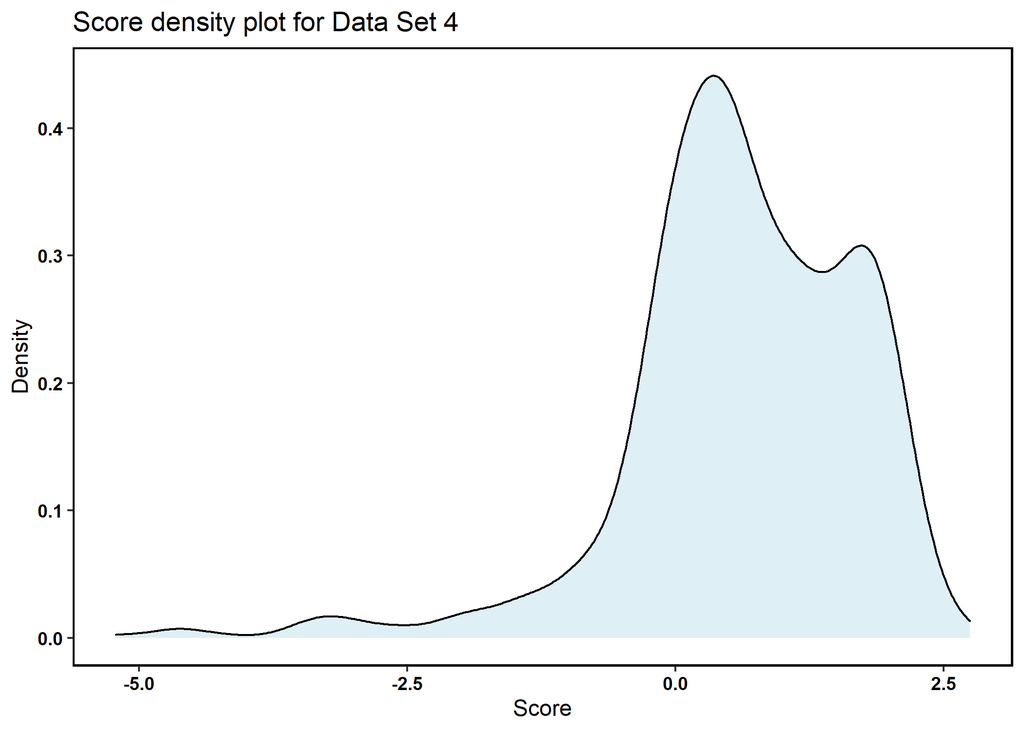

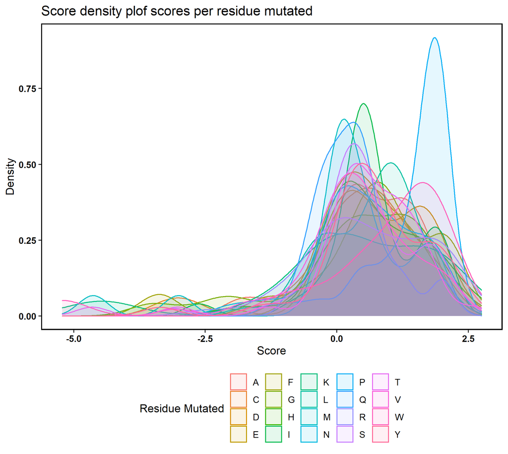

## Residues allowed in Pabl1 RRM2 domain

An amino acid was counted as active if score >0.

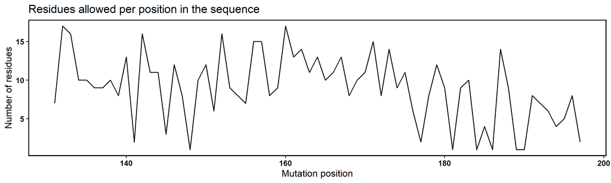

## Heatmap of Pabl1 RRM2 domain variant scores

The scoring scale was truncated to between -2…2.

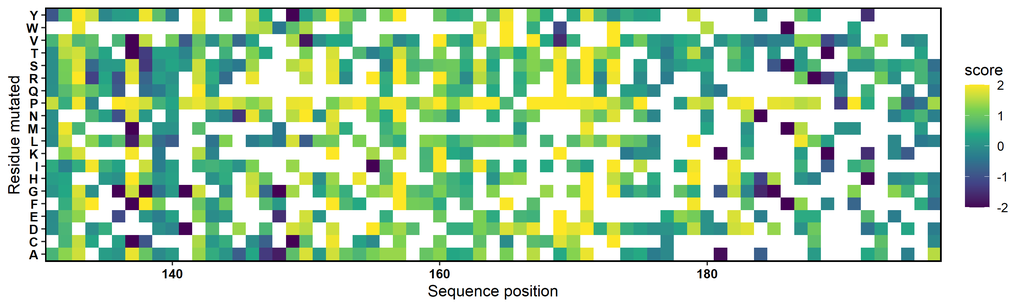

## Sequence logo of Pabl1 RRM2 domain(135-185) variant scores

The score was normalized and summed to 1 for each postion.

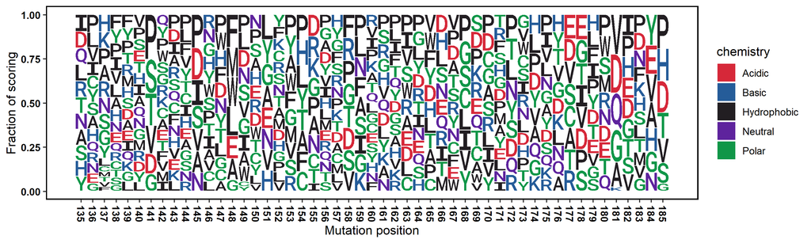

## Machine learning toolbox

- Supported machine learning framework:
  - Artificial Neutral Network (ANN) regression.
  - Regularized linear regression.

## Amino acid encoding

- In order to present the protein sequences to the ML framework we used amino acids descriptors.
- Each amino acid residue is converted to a vector and each protein as concatenation of vectors to yield a highly dimentional vector representation.
- The following amino acid scales are available:

| Scale(s) | Description of scale |
| --- | --- |
| blosum45,50,62,80,90 | Substitution matrix based on VARIMAX analysis of physicochemical properties |
| pam30,70,250 | Substitution matrix based on observed mutations in phylogenetic trees |
| z5_scales | PCA of physicochemical properties |

## Cross validation of a Pabl1 RRM2 glmnet model with z_scale

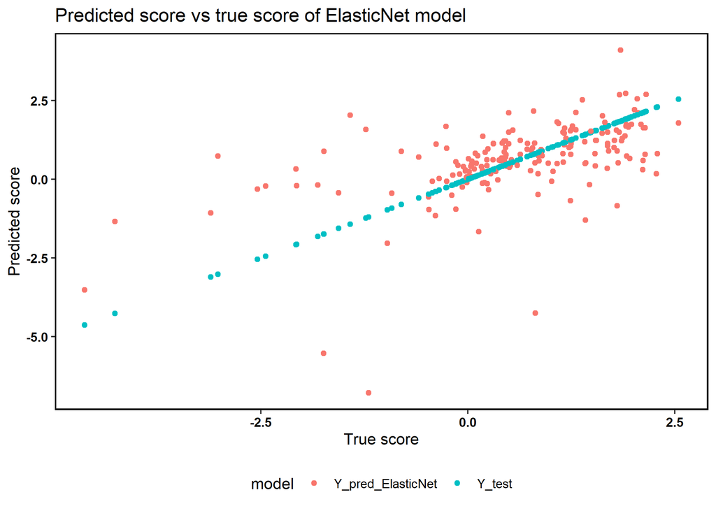

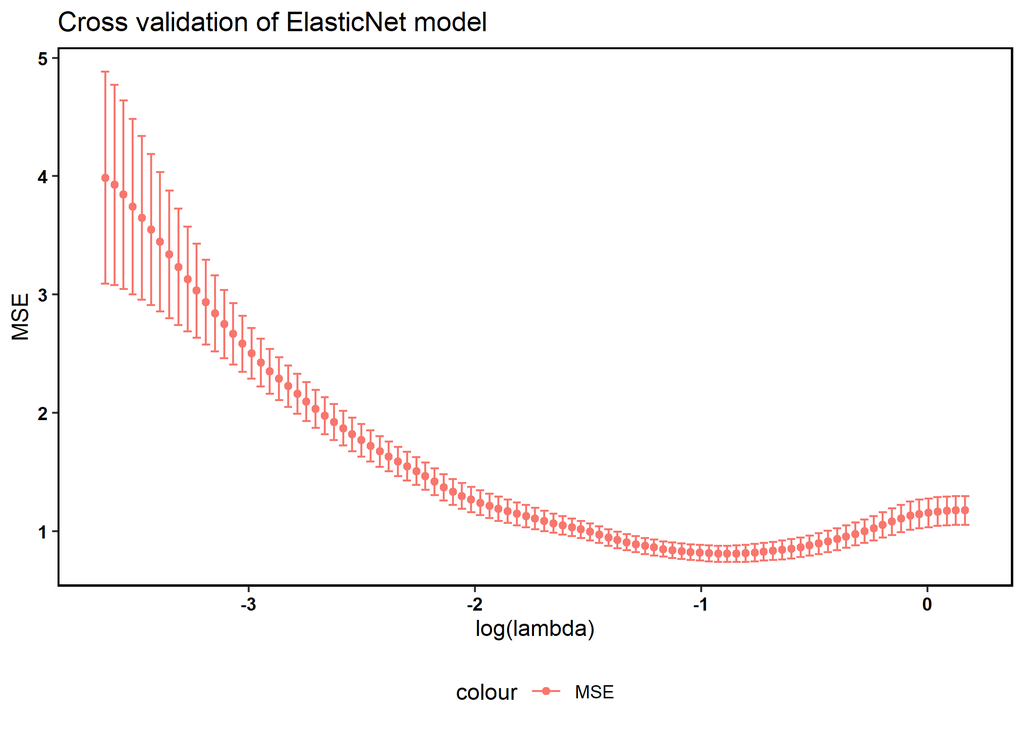

## Prediction of unknown Pabl1 RRM2 variants with ElasticNet and z_scales

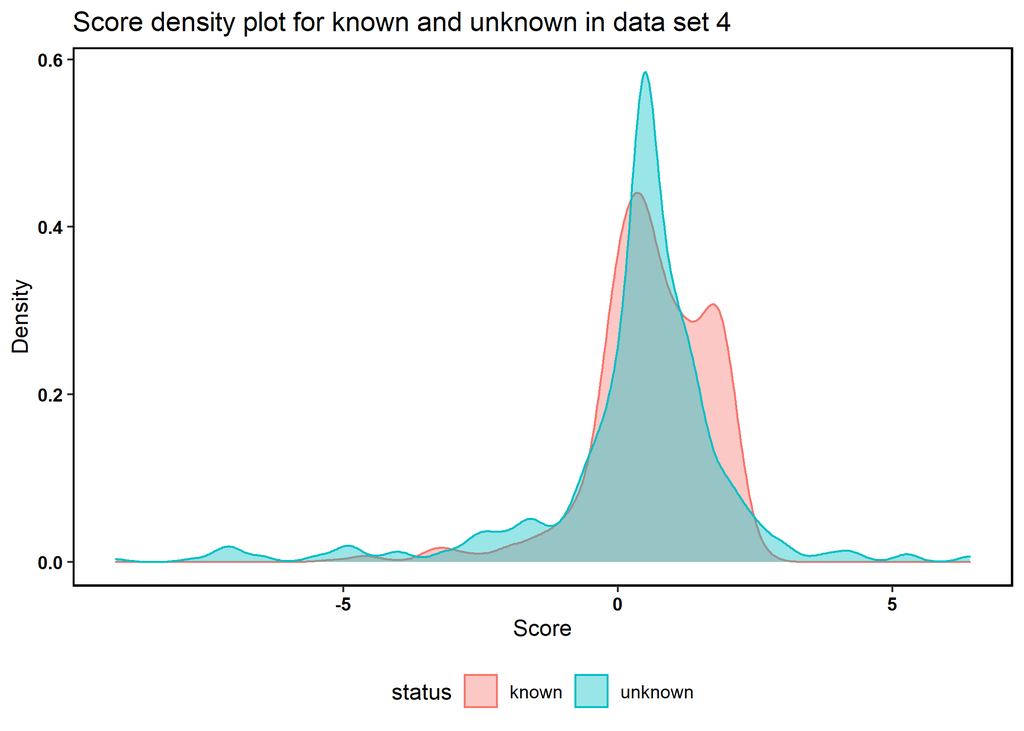

## Discussion and model comparison for all four data sets

[figure not shown]

- **Data set 1**: L. M. Starita, D. L. Young, et al. *Massively parallel functional analysis of brca1 ring domainvariants*, Genetics, vol. 200, no. 2, pp. 413–422, 2015.
- **Data set 2**: L. Brenan, A. Andreev, et al. *Phenotypic characterization of a comprehensive set of missense mutants*. Cell Reports, vol. 17, no. 4, pp. 1171–1183, 2016.
- **Data set 3**: A deep mutational scan of LDLRAP1 based on a Y2H assay with the interactor OBFC1. [https://www.mavedb.org/scoreset/urn:mavedb:00000036-a-1/]
- **Data set 4**: D. Melamed, D. L. Young, et al. *Combining natural sequence variation withhigh throughput mutational data to reveal protein interaction sites*. PLOS Genetics, vol. 11, no. 2,pp. 1–21, 2015.

## Score density collection

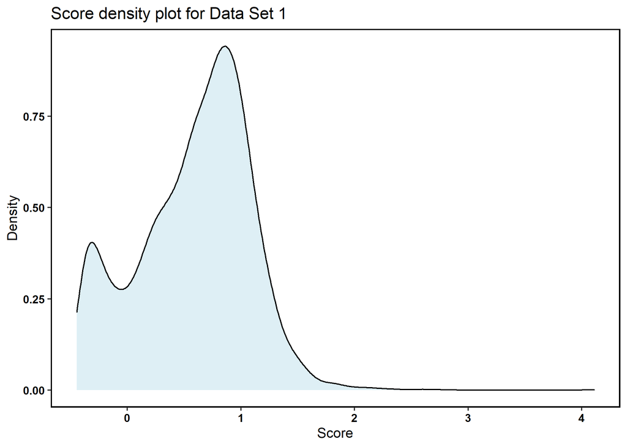

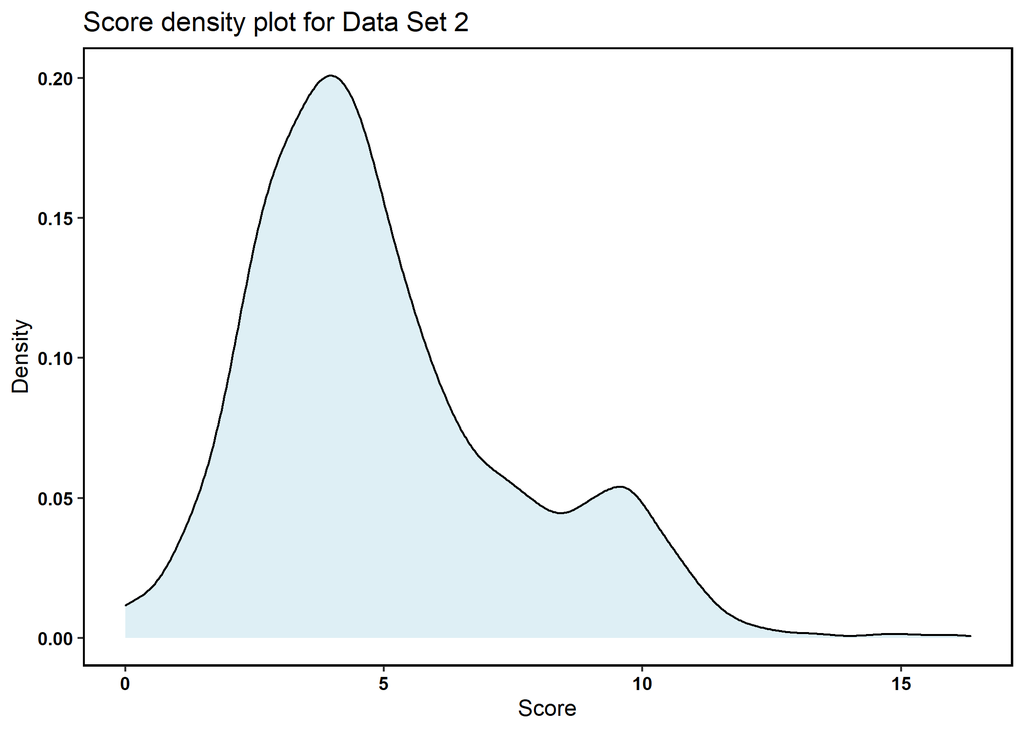

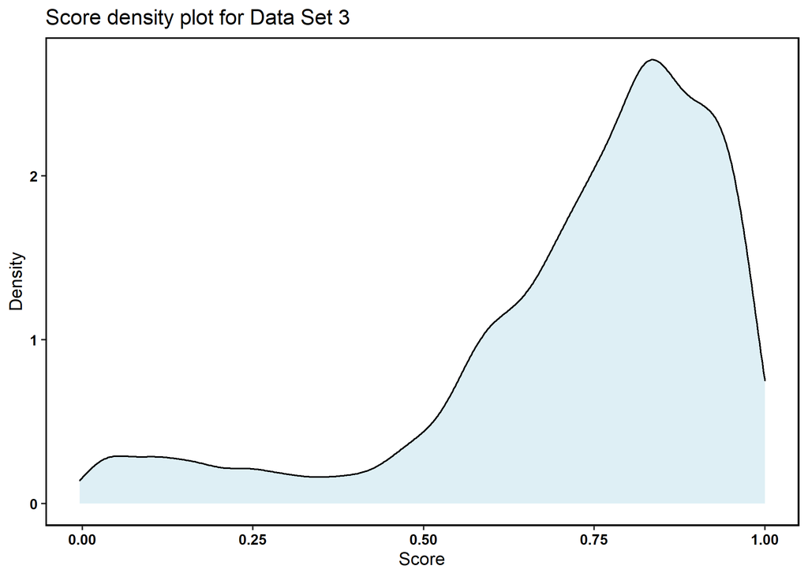

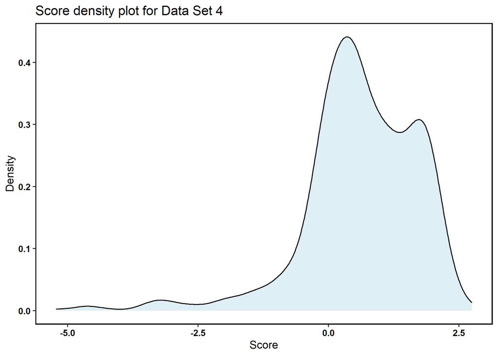

## Heatmap collection

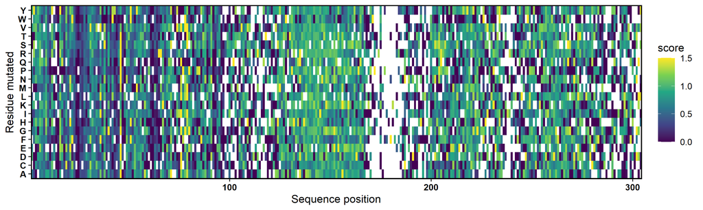

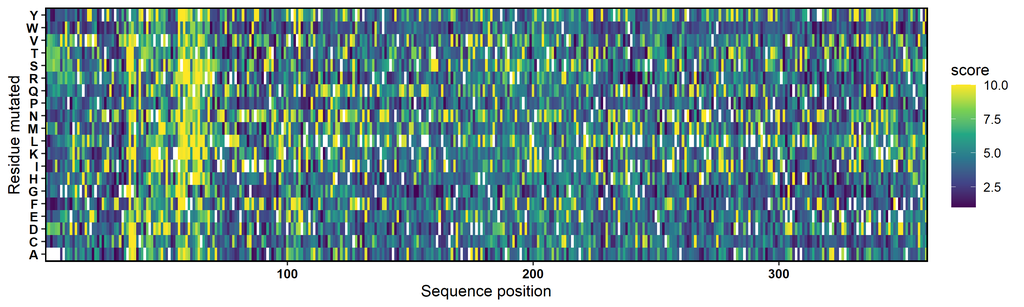

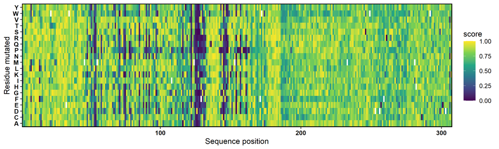

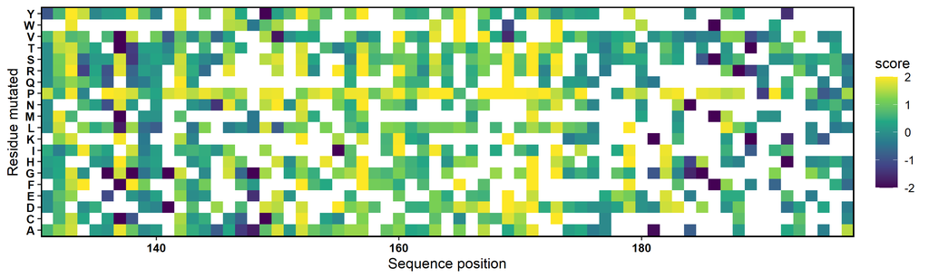

## Sequence logo collection

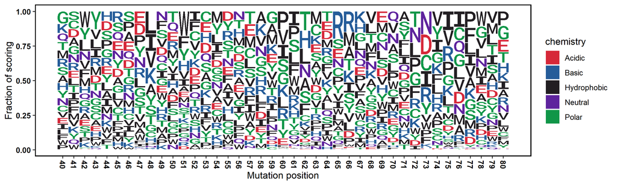

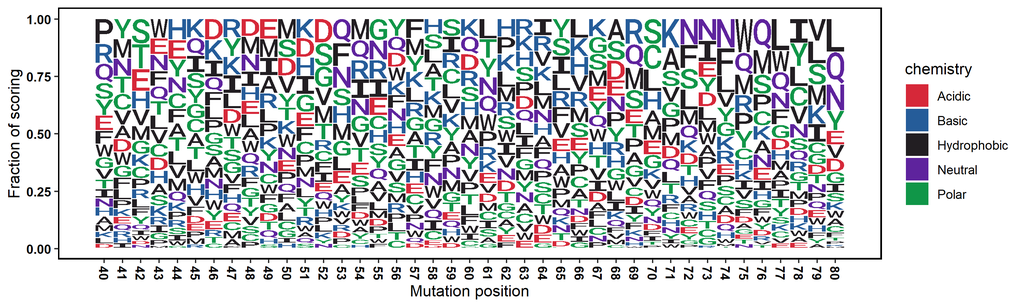

[figure not shown]

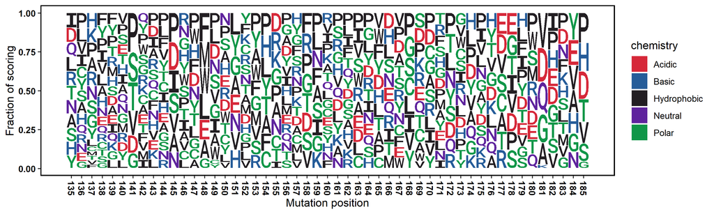

## Residues allowed collection

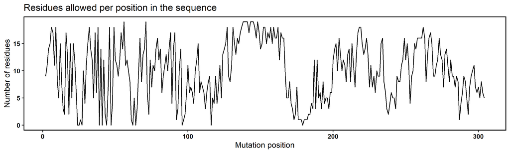

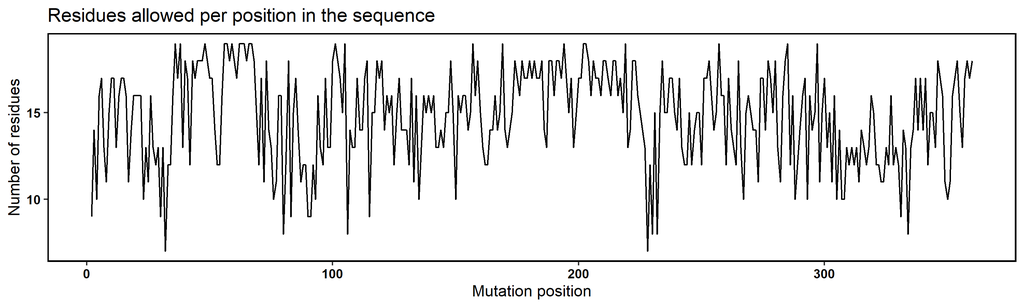

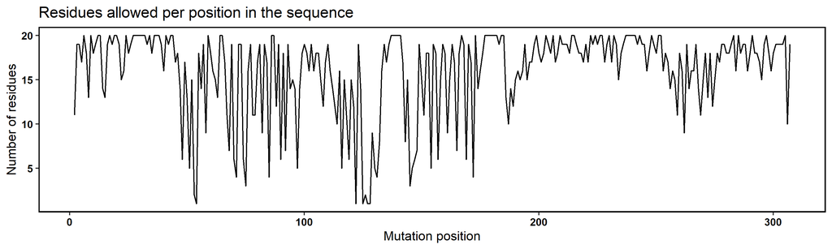

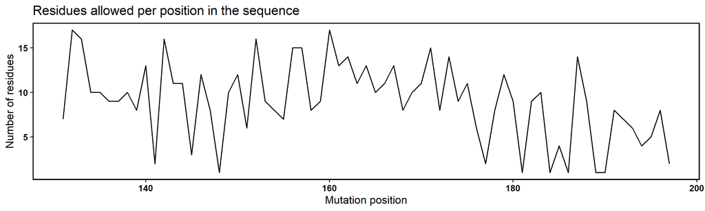

## Appendix

### R script overview 1

- 02_clean.R
  - Load: Load data from 01_load.R
  - Wrangle data: Remove NaN, fixes
  - Save cleansed data in .tsv format
- 03_augment.R
  - Load data from 02_clean.R
  - Augment data: Calculate sequences, descriptors (pI, MW, Z-Scale)
  - Save augmented data in .tsv format

## Appendix

### R script overview 2

- 04_model_i.R
  - Load augmented data
  - Perform model fitting
  - Predict unknowns
  - Plotting and reporting

## Appendix

### R script overview 3

- 99_proj_func.R
  - Sequence encoder
  - Sequence generator
  - Plot functions